# DS 202: Lab 3

MyTien Kien; kmytien, Tanner Dunn, tcdunn

3/1/2021

### Uploading Data

```r
library(dplyr)
```

```r
library(classdata)
library(ggplot2)

#Shows warnings?
dat <- readxl::read_xls('C:\\Spring2021\\ds202\\Lab3\\ds202_lab3\\GSS.xls')
#Renaming Columns & Cleaning
dat1 <- rename(dat, 'work_hours' = 'Number of hours usually work a week',
               'marital' = 'Marital status',
               'education' = 'Highest year of school completed',
               'gender' = 'Respondents sex',
               'num_household' = 'Number of persons in household',
               'party_affiliation' = 'Political party affiliation',
               'happiness' = 'General happiness')

dat1 <- dat1 %>%
    mutate(work_hours = factor(work_hours)) %>%
    mutate(education = as.numeric(education)) %>%
    mutate(happiness = factor(happiness)) %>%
    mutate(marital = factor(marital)) %>%
    mutate(party_affiliation = factor(party_affiliation)) %>%
    mutate(gender = factor(gender))
```

##### 1. Find the average years of education for the respondents with each marital status. Arrange your output in a meaningful order and print. Describe any patterns you find.

```r
dat1$marital <- factor(dat1$marital, levels = (c("Widowed", "Separated", "Married", "Divorced", "Never married", "No answer")))

dat2 <- dat1 %>%
    group_by(marital) %>%
    summarise(education_mean = mean(education, na.rm = TRUE)) %>%
    arrange(education_mean)

dat2
```

```
## # A tibble: 7 x 2
##   marital       education_mean
##   <fct>                  <dbl>
## 1 Widowed                 11.2
## 2 Separated               11.9
## 3 Married                 13.0
## 4 Divorced                13.1
## 5 Never married           13.4
## 6 No answer               15.5
## 7 <NA>                   NaN
```

It looks like the average for most people is around 11 to 13. The people who had the highest average years of education were those who did not answer. Out of those who did answer, those who never married had the highest average of education completed. Those who are widowed had the lowest average.

##### 2. Create a single data frame containing records for the better educated respondents with each marital status. A “better educated” respondent is someone who has strictly more years of education than the average among those with the same marital status. Print the structure of the data frame.

```r
better_educated <- dat1 %>%
    select(marital, education) %>%
    group_by(marital) %>%
    filter(education > mean(education, na.rm = TRUE)) %>%
    arrange(education)

str(better_educated)
```

```
## tibble [30,714 x 2] (S3: grouped_df/tbl_df/tbl/data.frame)
##  $ marital  : Factor w/ 6 levels "Widowed","Separated",..: 2 1 1 2 1 1 1 1 1 1 ...
##  $ education: num [1:30714] 12 12 12 12 12 12 12 12 12 12 ...
##  - attr(*, "groups")= tibble [6 x 2] (S3: tbl_df/tbl/data.frame)
##   ..$ marital: Factor w/ 6 levels "Widowed","Separated",..: 1 2 3 4 5 6
##   ..$ .rows  : list<int> [1:6]
##   .. ..$ : int [1:3538] 2 3 5 6 7 8 9 10 11 14 ...
##   .. ..$ : int [1:1458] 1 4 12 13 22 24 26 31 41 43 ...
##   .. ..$ : int [1:16040] 2449 2450 2451 2452 2453 2454 2455 2456 2457 2458 ...
##   .. ..$ : int [1:3414] 5602 5645 5712 5772 5774 5777 5838 5840 5841 5846 ...
##   .. ..$ : int [1:6250] 5583 5586 5590 5593 5594 5595 5603 5613 5618 5632 ...
##   .. ..$ : int [1:14] 18688 21679 21693 21975 22791 24609 25695 26632 27632 28024 ...
##   .. ..@ ptype: int(0)
##   ..- attr(*, ".drop")= logi TRUE
```

##### 3. How is the happiness of a respondent related to his/her marriage status? Define that a person is happy if the response to question is “Very happy” or “Pretty happy”.

```r
marital_happiness <- dat1 %>%
    select(marital, happiness) %>%
    group_by(marital) %>%
    count(happiness) %>%
    arrange(desc(marital), happiness)

marital_happiness
```

```
## # A tibble: 37 x 3
## # Groups:   marital [7]
##    marital       happiness          n
##    <fct>         <fct>          <int>
##  1 No answer     Don't know         1
##  2 No answer     No answer          1
##  3 No answer     Not applicable     5
##  4 No answer     Not too happy      4
##  5 No answer     Pretty happy      10
##  6 No answer     Very happy         6
##  7 Never married Don't know        10
##  8 Never married No answer         94
##  9 Never married Not applicable   992
## 10 Never married Not too happy   2055
## # ... with 27 more rows
```

It looks like those who are happy are those that are married, with over 29000 people saying they are “very/pretty happy”. We see that for every marital category, a lot of people are happy more than not, meaning they are okay with their marital status right now.

##### 4. Does party affiliation affect the relationship you found in the last question?

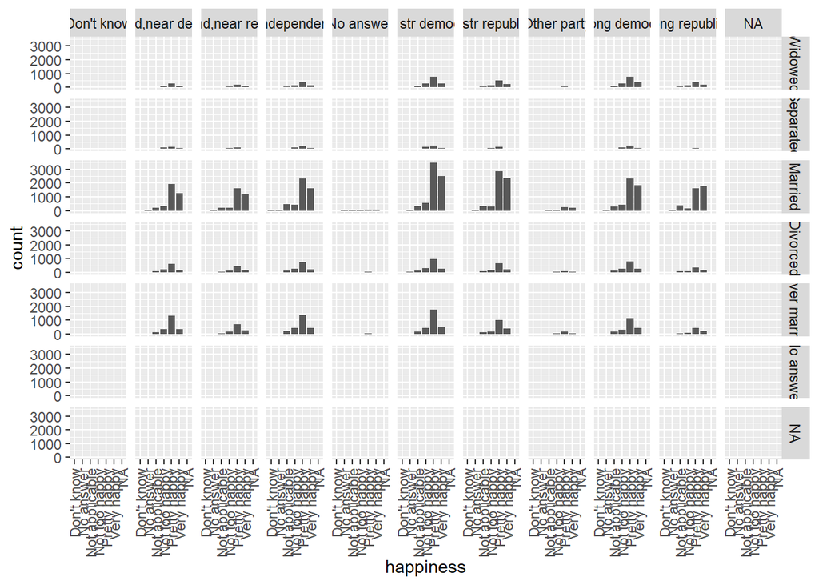

```r
ggplot(dat1, aes(x=happiness)) + geom_bar() +theme(axis.text.x=element_text(angle = 90,hjust=1,vjust=.5)) + facet_grid(marital ~ party_affiliation)
```

##### 5. How is marital status related to the education of a respondent? What are possible reasons accounting for the patterns you see?

```r
educ_marital <- dat1 %>%
    group_by(marital) %>%
    summarise(education_mean = mean(education, na.rm = TRUE)) %>%
    arrange(education_mean)

educ_marital
```

```
## # A tibble: 7 x 2
##   marital       education_mean
##   <fct>                  <dbl>
## 1 Widowed                 11.2
## 2 Separated               11.9
## 3 Married                 13.0
## 4 Divorced                13.1
## 5 Never married           13.4
## 6 No answer               15.5
## 7 <NA>                   NaN
```

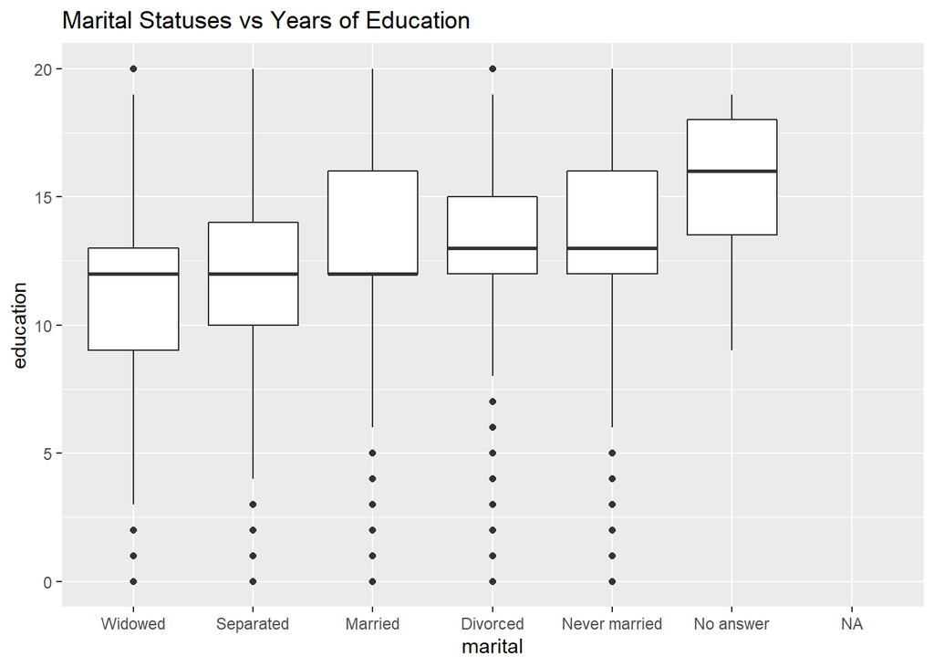

```r
ggplot(dat1, aes(x = marital, y = education)) + geom_boxplot() + ggtitle("Marital Statuses vs Years of Education")
```

If we’re looking at the average years of education, all marital statuses look pretty close to each other. I don’t think education makes much a difference when it comes to marital status. Those who were never married had the highest average rating of years of education, probably because they wanted to spend more time on school.

##### 6. Explore two more interesting questions, and answer those questions using the GSS data.

I wanted to know how the number of people in their household affected one’s happiness.

```r
household_happiness <- dat1 %>%
    group_by(num_household) %>%
    count(happiness) %>%
    arrange(desc(happiness))

household_happiness
```

```
## # A tibble: 71 x 3
## # Groups:   num_household [17]
##    num_household happiness      n
##            <dbl> <fct>      <int>
##  1             1 Very happy  3026
##  2             2 Very happy  7452
##  3             3 Very happy  3169
##  4             4 Very happy  2917
##  5             5 Very happy  1367
##  6             6 Very happy   536
##  7             7 Very happy   210
##  8             8 Very happy    77
##  9             9 Very happy    40
## 10            10 Very happy    19
## # ... with 61 more rows
```

Looking at these answers, I see that people are generally happy with fewer than 5 or so people in their household. A factor that I might not have considered was how many people actually had up to 15 people in their household (assuming it’s not a lot, so not many people for that answered). But overall, many people responded very happy to having 1-4 people in their home.

The second thing we wanted to look at is if gender had an effect on happiness.

```r
gender_happiness <- dat1 %>%
    group_by(gender) %>%
    count(happiness) %>%
    arrange(desc(happiness))

gender_happiness
```

```
## # A tibble: 13 x 3
## # Groups:   gender [3]
##    gender happiness          n
##    <fct>  <fct>          <int>
##  1 Female Very happy     10683
##  2 Male   Very happy      8140
##  3 Female Pretty happy   18544
##  4 Male   Pretty happy   15019
##  5 Female Not too happy   4312
##  6 Male   Not too happy   3356
##  7 Female Not applicable  2443
##  8 Male   Not applicable  1940
##  9 Female No answer        195
## 10 Male   No answer        143
## 11 Female Don't know        23
## 12 Male   Don't know        16
## 13 <NA>   <NA>               2
```

Looking at this it appears that there is a larger amount of women that would be considered happier but there are actually more women than men in this data set. Therefore when you look at the percentage of Male and Female’s considered to be happy, they both are right around 81%, meaning according to this data gender doesn’t have much of an impact on happiness.